# R Notebook

```r
library(rpart)
library(rpart.plot)
library(tidyverse)

library(tidyverse)
titanic_set <- read_csv('data/titanic_decision_tree_data.csv')
shuffle_index <- sample(1:nrow(titanic_set))

# shuffle the data so class order isn't in order - need this for training/testing split later on
titanic_set <- titanic_set[shuffle_index, ]
```

## Question 1.1

```r
titanic_clean <- titanic_set %>%
  drop_na() %>%
  mutate(sex = as.factor(sex),
         survived = factor(survived, levels = c(0, 1), labels = c("No", "Yes")),
         class = factor(pclass, levels = c(1, 2, 3), labels = c("Upper", "Middle", "Lower")),
         embarked = as.factor(embarked),
         age_status = as.factor(if_else(age <= 16, "child", "adult"))
         ) %>%
  select(sex, survived, class, embarked, age_status, sib_sp, parch)
```

## Question 1.2

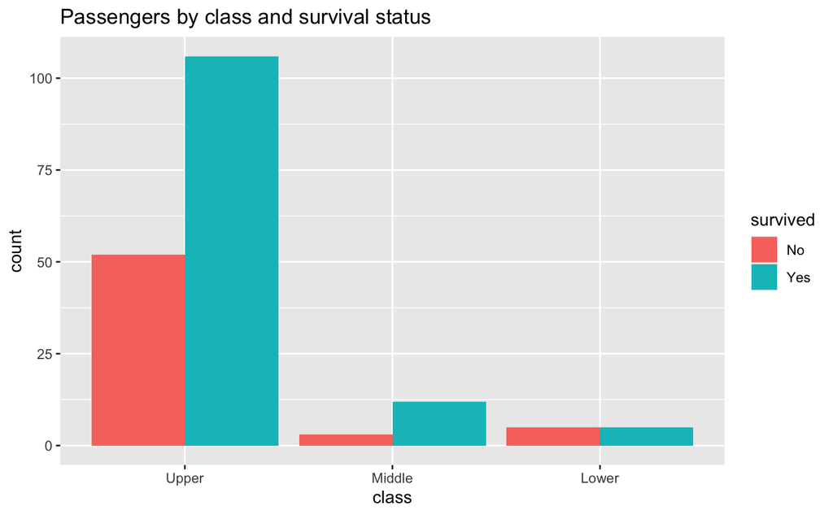

```r
titanic_clean %>%
  ggplot() +
  aes(x = class, fill = survived) +
  geom_bar(position = "dodge") +
  labs(
    title = "Passengers by class and survival status"
  )
```

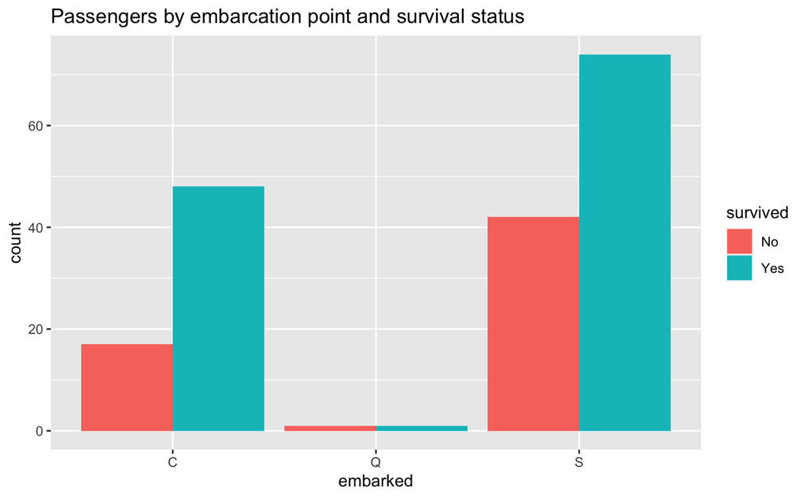

```r
titanic_clean %>%
  ggplot() +
  aes(x = embarked, fill = survived) +
  geom_bar(position = "dodge") +
  labs(
    title = "Passengers by embarcation point and survival status"
  )
```

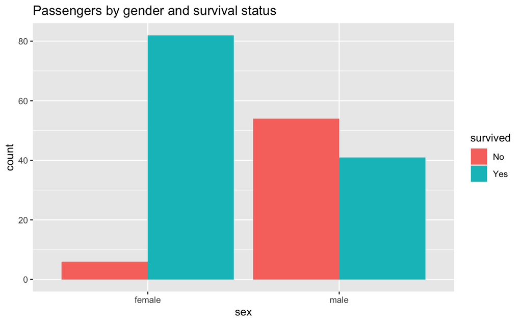

```r
titanic_clean %>%
  ggplot() +
  aes(x = sex, fill = survived) +
  geom_bar(position = "dodge") +
  labs(
    title = "Passengers by gender and survival status"
  )
```

Many more of the wealthier survived.

More of those joining in Cherbourg and Southampton survived

More women survived than men.

Variables of use: class, sex, embarcation point

## Question 3

```r
# number of rows in dataset
n_data <- nrow(titanic_set)

# create a test sample index
test_index <- sample(1:n_data, size = n_data * 0.2)

# create test set
titanic_test  <- slice(titanic_clean, test_index)

# create training set
titanic_train <- slice(titanic_clean, -test_index)
```

```r
titanic_test %>%
  tabyl(survived)
```

```
 survived  n   percent
       No 13 0.3513514
      Yes 24 0.6486486
```

```r
titanic_train %>%
  tabyl(survived)
```

```
 survived  n   percent
       No 47 0.3219178
      Yes 99 0.6780822
```

The split is fairly even!

## Question 4

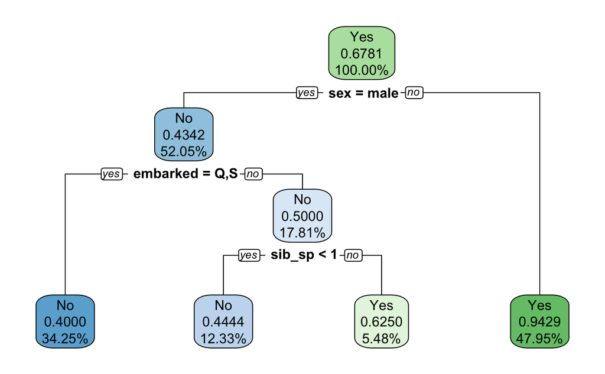

```r
titanic_fit <- rpart(
  formula = survived ~ .,
  data = titanic_train,
  method = "class"
)

rpart.plot(titanic_fit,
           yesno = 2,
           fallen.leaves = TRUE,
           faclen = 6,
           digits = 4)
```

## Question 5

The top node indicates that the most likely outcome for passengers is `survival`. Yeah! Almost 68% of passengers survived from this data sample.

Moving down to the second level (below the root node): If you were female, you were likely to survive (94.29%). Females accounted for 48% of the total passengers. If you were male, you only had a 43.42% chance of survival despite making up 52% of the total passengers.

For those males from Cherbourg with family, you were more likely to survive (62.5%) than if you had no family with you (44.44%).

# Question 6

| sex | survived | class | embarked | age_status | sib_sp | parch | pred |
| --- | --- | --- | --- | --- | --- | --- | --- |
| male | No | Upper | S | adult | 0 | 0 | No |
| male | Yes | Middle | S | child | 1 | 1 | No |
| female | No | Upper | S | adult | 1 | 2 | Yes |
| female | No | Upper | S | child | 1 | 2 | Yes |
| male | No | Upper | S | adult | 0 | 0 | No |
| male | No | Upper | C | adult | 0 | 0 | No |
| female | Yes | Upper | S | adult | 3 | 2 | Yes |
| female | Yes | Upper | C | adult | 2 | 2 | Yes |
| female | Yes | Upper | S | adult | 0 | 0 | Yes |
| male | No | Upper | S | adult | 0 | 0 | No |

[output cut: 27 more lines]

```r
library(yardstick)

conf_mat <- titantic_test_pred %>%
  conf_mat(truth = survived, estimate = pred)

conf_mat
```

```
          Truth
Prediction No Yes
       No  11   7
       Yes  2  17
```

The model correctly predicted that 11 passengers died and that 17 passengers survived.

The model incorrectly predicted that 7 passengers died when in fact they survived (false negative).

The model incorrectly predicted that 2 passengers survived when in fact they died (false positive).

| .metric | .estimator | .estimate |
| --- | --- | --- |
| accuracy | binary | 0.7567568 |

The model is 76% accurate.